# PML - Course Project

December 26, 2015

## Data Preparation

The initial data is in a raw form with some blanks and error codes. We set these to NA in our read statement.

```r
library(caret)
```

```r
download.file(url='https://d396qusza40orc.cloudfront.net/predmachlearn/pml-training.csv',
              destfile='./PML_train.csv')

#Read in data setting empty and error values to NA.
WL <- read.csv('./PML_train.csv',na.strings = c("NA","#DIV/0!",""),as.is = TRUE)
WL <- data.frame(WL)
```

Create a training and test set to estimate out of sample error.

```r
inTrain <- createDataPartition(y = WL$classe, p=.75, list = F)
WLtrain <- WL[inTrain,]
WLtest <- WL[-inTrain,]
```

The predictors are to be measurments from various sensors worn by the participants. Thus for predition purposes I’ll ignore the first 6 columns which are participant name, timestamps, and other experiment variables.

```r
exp_vars <- grep("X|user_name|raw_timestamp_part_1|raw_timestamp_part_2|cvtd_timestamp|num_window",names(WLtrain))
WLtrain <- WLtrain[,-exp_vars]
```

A number of the predictors still have many missing values. There are only 221 complete observations all of the predictors. I’ve fit a Gradient Boosting Machine with the complete dataset with missing values, but accuracy was only 49.93% (not shown). Far greater accuracy can be achieved by removing the variables with missing values.

```r
#clean variables with missing values
null_count <- sapply(WLtrain, function(x) sum(is.na(x)))
keep <- null_count==0
WLtrain <- WLtrain[,keep]
```

The prediction target is the classe variable. We’ll make this a factor and look at a quick frequency and plot it by two of the most important varaibles.

```r
WL$classe <- factor(WL$classe)
table(WL$classe)
```

```
##
##    A    B    C    D    E
## 5580 3797 3422 3216 3607
```

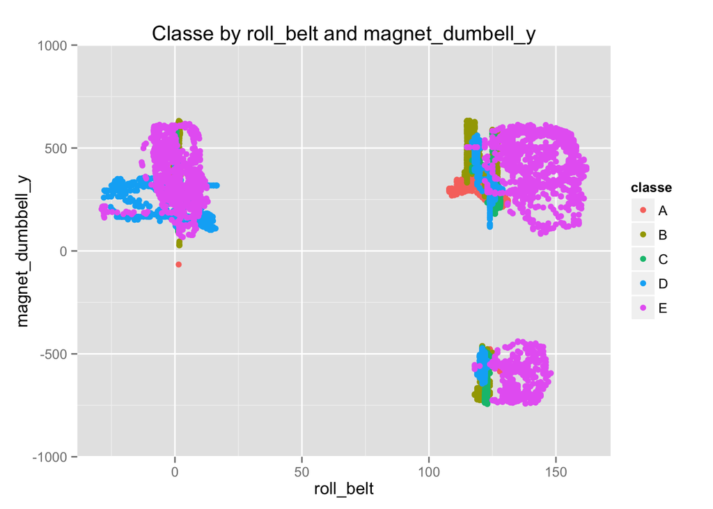

```r
library(ggplot2)
ggplot(aes(x=roll_belt,y=magnet_dumbbell_y,colour=classe), data=WLtrain) + geom_point() + coord_cartesian(ylim = c(-1000,1000)) + ggtitle("Classe by roll_belt and magnet_dumbell_y")
```

## Modeling

We’ll fit a random forrest to the model. We’ll use 5 fold cross validation in the train control to help mitigate potential overfitting.

```r
Control1 <- trainControl(method = "cv", number = 5)
modFit1 <- train(classe ~ ., data=WLtrain, method ="rf", importance = T, trControl = Control1)
modFit1
```

```
## Random Forest
##
## 14718 samples
##    53 predictor
##     5 classes: 'A', 'B', 'C', 'D', 'E'
##
## No pre-processing
## Resampling: Cross-Validated (5 fold)
## Summary of sample sizes: 11776, 11774, 11775, 11774, 11773
## Resampling results across tuning parameters:
##
##   mtry  Accuracy   Kappa      Accuracy SD  Kappa SD
##    2    0.9914388  0.9891694  0.002234366  0.002827182
##   27    0.9925263  0.9905457  0.001223866  0.001548223
##   53    0.9858002  0.9820364  0.003285244  0.004156341
##
## Accuracy was used to select the optimal model using  the largest value.
## The final value used for the model was mtry = 27.
```

We can examine the selection process as predictors were added.

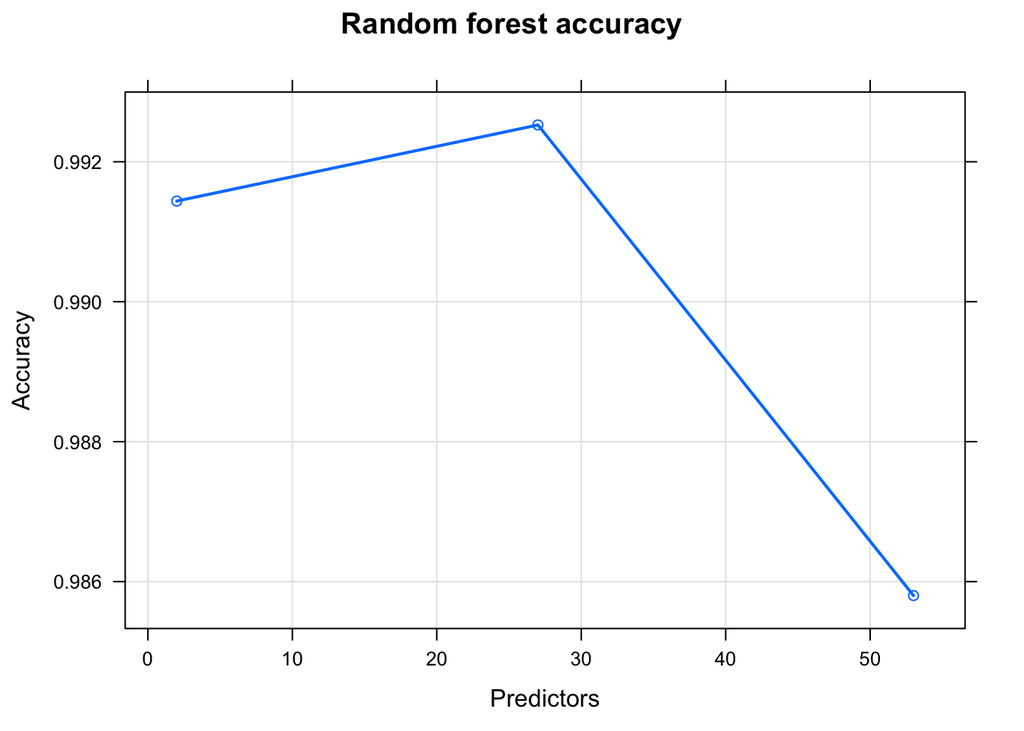

```r
plot(modFit1, log = "y", lwd = 2, main = "Random forest accuracy", xlab = "Predictors",  ylab = "Accuracy")
```

```r
varImp(modFit1)
```

```
## rf variable importance
##
##   variables are sorted by maximum importance across the classes
##   only 20 most important variables shown (out of 53)
##
##                       A     B     C     D      E
## roll_belt         78.81 82.84 80.71 81.32 100.00
## pitch_belt        34.64 98.28 65.84 51.22  43.44
## pitch_forearm     61.97 78.82 95.27 63.86  65.47
## magnet_dumbbell_y 75.28 75.24 89.27 69.31  64.68
## yaw_belt          63.35 67.25 66.92 79.62  52.40
## magnet_dumbbell_z 78.95 62.23 77.48 57.46  58.99
## accel_forearm_x   25.98 43.06 36.20 53.19  39.87
## roll_forearm      52.81 44.84 50.15 40.13  40.23
## gyros_dumbbell_y  45.62 32.76 43.66 34.73  33.46
## yaw_arm           45.47 36.50 31.81 37.86  24.38
## gyros_belt_z      30.92 34.04 39.03 29.41  45.03
## accel_dumbbell_y  38.22 38.11 44.75 37.22  37.20
## accel_dumbbell_z  33.65 37.99 31.34 36.61  43.76
## roll_dumbbell     25.86 40.37 25.56 28.07  36.78
## magnet_arm_z      26.88 38.64 26.94 28.33  25.55
## magnet_belt_z     29.07 37.81 29.92 37.74  33.87
## magnet_belt_x     22.33 37.62 32.96 24.44  34.37
## magnet_belt_y     23.22 36.62 33.99 28.28  33.06
## magnet_forearm_z  35.68 35.77 34.49 33.01  36.61
## gyros_arm_y       31.87 36.60 32.09 35.22  28.21
```

## Out of Sample Error Prediction

To estimate the out of sample error we apply the prediction to the test set.

```r
test.Predict = predict(modFit1, WLtest)
confusionMatrix(test.Predict,WLtest$classe)
```

```
## Confusion Matrix and Statistics
##
##           Reference
## Prediction    A    B    C    D    E
##          A 1392    2    0    0    0
##          B    3  947    7    0    1
##          C    0    0  846   17    2
##          D    0    0    2  786    3
##          E    0    0    0    1  895
##
## Overall Statistics
##
##                Accuracy : 0.9923
##                  95% CI : (0.9894, 0.9945)
##     No Information Rate : 0.2845
##     P-Value [Acc > NIR] : < 2.2e-16
##
##                   Kappa : 0.9902
##  Mcnemar's Test P-Value : NA
##
## Statistics by Class:
##
##                      Class: A Class: B Class: C Class: D Class: E
## Sensitivity            0.9978   0.9979   0.9895   0.9776   0.9933
## Specificity            0.9994   0.9972   0.9953   0.9988   0.9998
## Pos Pred Value         0.9986   0.9885   0.9780   0.9937   0.9989
## Neg Pred Value         0.9991   0.9995   0.9978   0.9956   0.9985
## Prevalence             0.2845   0.1935   0.1743   0.1639   0.1837
## Detection Rate         0.2838   0.1931   0.1725   0.1603   0.1825
## Detection Prevalence   0.2843   0.1954   0.1764   0.1613   0.1827
## Balanced Accuracy      0.9986   0.9976   0.9924   0.9882   0.9965
```